# Planning an Airport Screening Queue with Erlang C

A reproducible M/M/c case study using synthetic event timestamps

Reway Du

Portfolio edition — August 2026

# 1 Executive summary

This portfolio project asks a practical planning question: **given independently observed passenger arrivals, service durations, and the number of parallel screening servers, which operating periods are likely to miss a target of 85% of passengers waiting no more than 10 minutes?**

The analysis estimates arrival rates ($\lambda$) from arrival counts and scheduled exposure, and service rates ($\mu$) from the elapsed time between separate service start and service end timestamps. Waiting time is reserved for validation; it is **not** used to back-solve processing capacity.

The fitted model flags the morning and afternoon peaks. Their predicted 10-minute service levels are 69.6% and 81.1%, respectively, compared with the 85% goal. On the later chronological holdout, the observed values are 78.1% and 74.0%. The mean absolute validation error across all four periods is 4.0 pp; all four holdout estimates do not all fall inside the training parameter-bootstrap bands. Those bands describe uncertainty from resampling training dates; they are not formal holdout predictive intervals.

> **Scope warning.** All people, timestamps, and operating conditions are synthetic. The results demonstrate an analytical workflow; they are not evidence about a real airport and must not be used as staffing advice.

# 2 Data design and temporal split

The included generator creates a fictional first-come, first-served screening system with four two-hour operating windows per day. Passenger arrivals follow a Poisson process, service durations are exponential, and each operating window has a fixed number of identical parallel servers. Two hours of warm-up events are simulated but excluded before the measured window begins.

The released event table contains only synthetic identifiers and operational timestamps:

- `arrival_time`: when a passenger joins the queue;
- `service_start_time`: when screening begins;
- `service_end_time`: when screening ends;
- `server_id` and `servers_scheduled`: synthetic resource identifiers and staffing;
- `service_date` and `period`: the operating window.

There are 40,145 measured passenger events. The first 56 dates (2026-01-05 through 2026-03-01) estimate the model. The final 28 dates (2026-03-02 through 2026-03-29) are untouched until validation. This chronological split prevents future waiting outcomes from influencing parameter estimation.

# 3 Queueing model

For each operating period, the maximum-likelihood rate estimates are

$$\widehat{\lambda} = \frac{\text{passenger arrivals}}{\text{scheduled
exposure hours}},
\qquad
\widehat{\mu} = \frac{\text{completed services}}{\text{total service
hours}}.$$

Here, $\mu$ is the service rate of **one** parallel server, and $c$ is the number of scheduled servers. Traffic intensity is

$$\rho = \frac{\lambda}{c\mu}.$$

A steady-state distribution exists only when $\rho < 1$. For a stable M/M/$c$ queue, the Erlang-C probability that a passenger must wait is

$$C(\lambda,\mu,c)=
\frac{\frac{a^c}{c!(1-\rho)}}
{\sum_{k=0}^{c-1}\frac{a^k}{k!}+\frac{a^c}{c!(1-\rho)}},
\qquad a=\frac{\lambda}{\mu}.$$

The predicted probability of waiting no more than $t$ hours is

$$P(W_q \le t)=1-C(\lambda,\mu,c)e^{-(c\mu-\lambda)t},$$

and the expected queue wait is

$$E(W_q)=\frac{C(\lambda,\mu,c)}{c\mu-\lambda}.$$

The implementation evaluates Erlang C on the log scale for numerical stability and returns no finite steady-state service level when $\rho \ge 1$.

# 4 Estimated operating conditions

```r
estimates %>%
  transmute(
    Period = as.character(period),
    `Training passengers` = training_passengers,
    `Arrivals / hour` = round(lambda_hat, 1),
    `Services / server-hour` = round(mu_hat, 1),
    Servers = servers,
    Utilization = fmt_percent(utilization),
    `Predicted within 10 min` = fmt_percent(model_service_level),
    `Expected wait (min)` = round(model_mean_wait_minutes, 1)
  ) %>%
  kable(
    align = c("l", "r", "r", "r", "r", "r", "r", "r"),
    caption = "Training-period M/M/c estimates."
  )
```

Training-period M/M/c estimates.

| Period | Training passengers | Arrivals / hour | Services / server-hour | Servers | Utilization | Predicted within 10 min | Expected wait (min) |
| --- | --- | --- | --- | --- | --- | --- | --- |
| Morning peak | 9437 | 84.3 | 15.0 | 6 | 93.4% | 69.6% | 8.3 |
| Midday | 5891 | 52.6 | 15.2 | 5 | 69.3% | 99.2% | 0.9 |
| Afternoon peak | 7488 | 66.9 | 15.0 | 5 | 89.1% | 81.1% | 5.4 |
| Evening | 3846 | 34.3 | 14.8 | 4 | 57.8% | 99.6% | 0.6 |

Morning demand consumes about 93.4% of estimated capacity. This is the most fragile period: a small demand increase or service slowdown sharply increases waits. Afternoon peak is also below the service-level goal, while midday and evening retain more spare capacity.

# 5 Uncertainty and sensitivity

The reported 95% intervals come from 500 nonparametric bootstrap samples of whole training dates within each operating period. Resampling dates, rather than individual passengers, keeps each day’s arrivals and service durations together. This quantifies finite-sample uncertainty in both rate estimates. It does not cover structural errors such as non-Poisson arrivals or time-varying service rates.

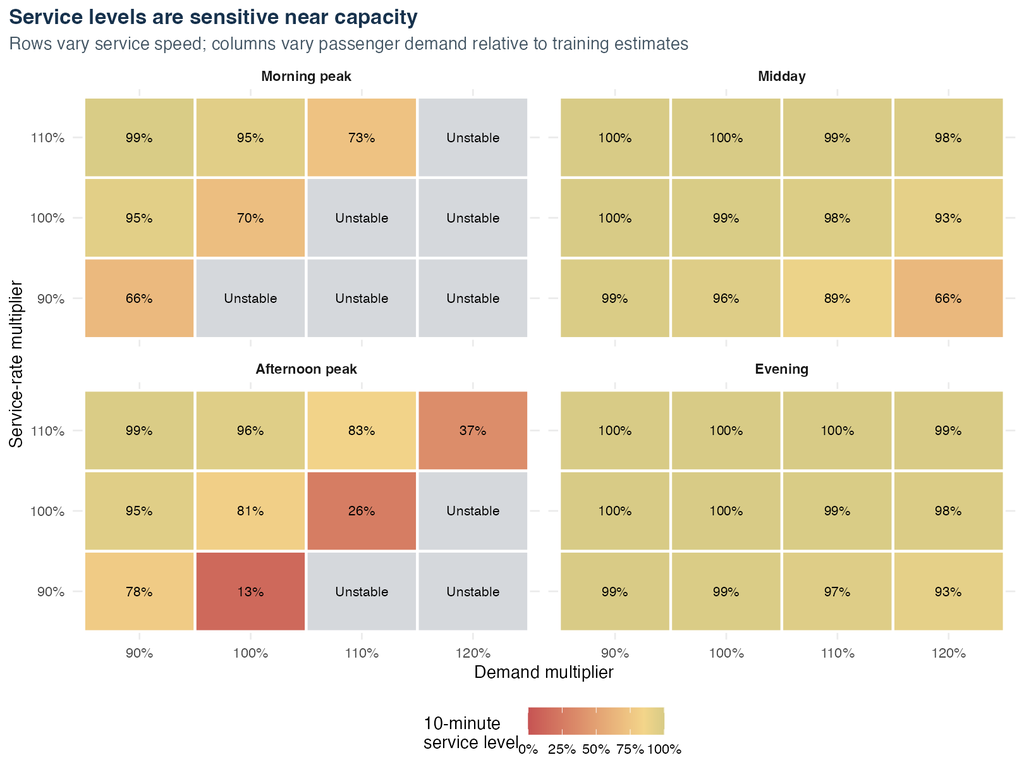

The sensitivity grid changes demand from 90% to 120% of the training estimate and service speed from 90% to 110%. Blank-grey/“Unstable” cells have $\rho \ge 1$, so a steady-state waiting-time probability does not exist. The peak periods deteriorate fastest because they have the smallest capacity buffer.

# 6 Chronological holdout validation

Waiting timestamps are used only here, after model fitting. The empirical service level is the proportion of holdout passengers whose elapsed time from arrival to service start is no more than 10 minutes.

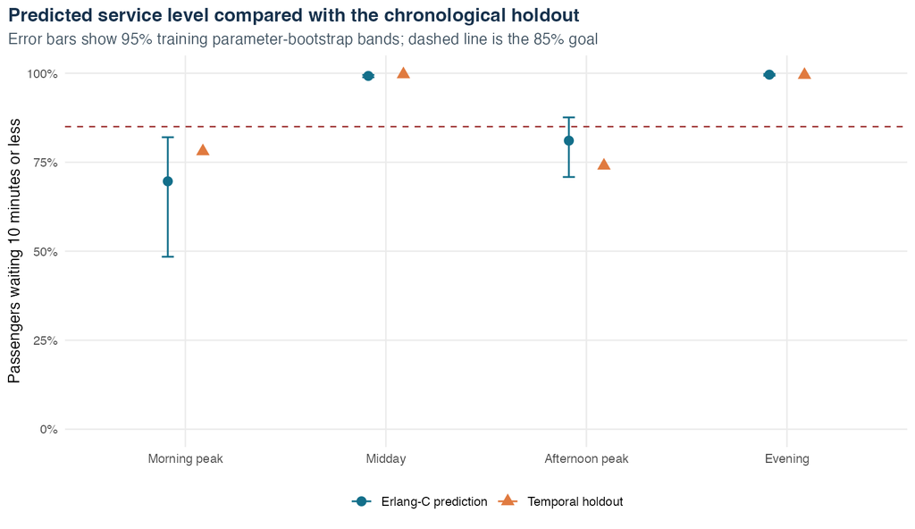

```r
validation %>%
  transmute(
    Period = as.character(period),
    `Holdout passengers` = holdout_passengers,
    `Model service level` = fmt_percent(model_service_level),
    `Holdout service level` = fmt_percent(observed_service_level),
    `Error (percentage points)` = round(service_level_error_pp, 1),
    `Model mean wait` = round(model_mean_wait_minutes, 1),
    `Holdout mean wait` = round(observed_mean_wait_minutes, 1)
  ) %>%
  kable(
    align = c("l", "r", "r", "r", "r", "r", "r"),
    caption = "Out-of-time validation on the final 28 dates."
  )
```

Out-of-time validation on the final 28 dates.

| Period | Holdout passengers | Model service level | Holdout service level | Error (percentage points) | Model mean wait | Holdout mean wait |
| --- | --- | --- | --- | --- | --- | --- |
| Morning peak | 4700 | 69.6% | 78.1% | -8.4 | 8.3 | 6.3 |
| Midday | 2887 | 99.2% | 99.7% | -0.4 | 0.9 | 1.0 |
| Afternoon peak | 3839 | 81.1% | 74.0% | 7.0 | 5.4 | 6.4 |
| Evening | 2057 | 99.6% | 99.5% | 0.1 | 0.6 | 0.9 |

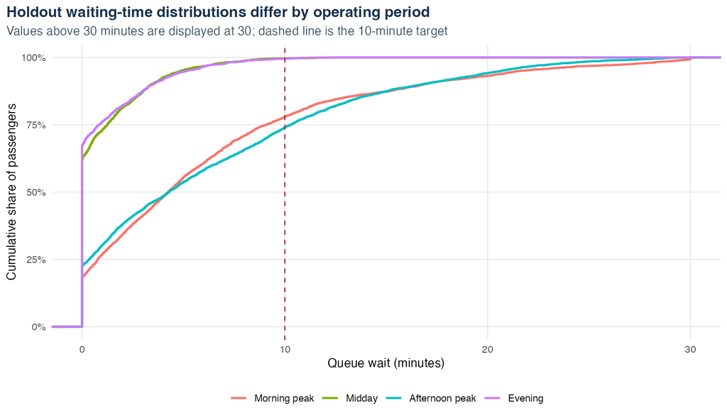

# 7 Staffing scenarios

For each period, the analysis searches for the smallest integer $c$ that is stable and reaches the 85%/10-minute target. The stress case combines 15% more demand with service that is 5% slower. These are scenario calculations, not causal estimates of what one extra staff member would accomplish in practice.

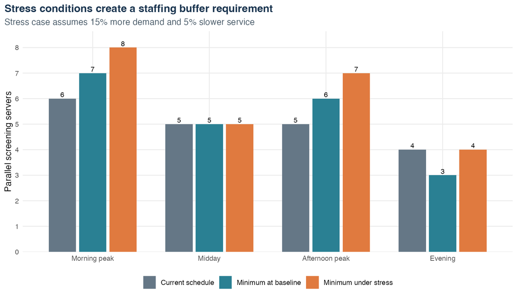

```r
staffing %>%
  transmute(
    Period = as.character(period),
    `Current servers` = current_servers,
    `Minimum at baseline` = minimum_servers_baseline,
    `Minimum under stress` = minimum_servers_stress,
    `Stress gap vs current` = stress_gap
  ) %>%
  kable(
    align = c("l", "r", "r", "r", "r"),
    caption = "Server counts required by the fitted M/M/c scenarios."
  )
```

Server counts required by the fitted M/M/c scenarios.

| Period | Current servers | Minimum at baseline | Minimum under stress | Stress gap vs current |
| --- | --- | --- | --- | --- |
| Morning peak | 6 | 7 | 8 | 2 |
| Midday | 5 | 5 | 5 | 0 |
| Afternoon peak | 5 | 6 | 7 | 2 |
| Evening | 4 | 3 | 4 | 0 |

# 8 Assumptions and limitations

The M/M/$c$ interpretation depends on the following assumptions:

1. arrivals are approximately Poisson within each modeled period;
2. service durations are approximately independent and exponential;
3. servers are parallel, identical, continuously available, and follow a first-come, first-served discipline;
4. arrival and service rates are constant within a period;
5. the queue has reached a steady operating regime; and
6. customers do not abandon, switch queues, or receive priority service.

The synthetic generator intentionally follows these assumptions, so the holdout exercise validates the implementation under controlled conditions—not the external validity of Erlang C at a real checkpoint. Real operations would need diagnostic tests, staffing breaks and downtime, interval-specific rates, abandonment, priority lanes, and uncertainty in future demand. A discrete-event simulation would be preferable when these features materially affect service.

# 9 Reproducibility and disclosure

Run `Rscript scripts/run_all.R` from the repository root to regenerate the data, tests, results, figures, and this report. The random seeds, generator parameters, and temporal split are fixed in source control.

This is an independent portfolio rewrite inspired by a collaborative university course(STA4320) exercise. No original course dataset, instructor material, real passenger record, or student identifier is included. The archived group statement records Reway Du and one teammate as sharing Task 3 and credits Reway with overall formatting, a float fix, and an observation correction; this report does not claim sole authorship of the earlier work. Obtain any teammate or instructor permission needed to mention the exercise publicly.

AI assistance was used to help redesign, document, and test this portfolio version.